# Radial Basis Function Networks

This notebook will examine the effectiveness of training a Radial Basis Function (RBF) network for a binary classification task on a two-dimensional dataset with 500 instances.

First we must load the dataset:

```r
library("corpcor")
circle<-read.table("circle.txt",sep=",",header=T)
circle
```

| V1 | V2 | labels |
| --- | --- | --- |
| -0.36125433 | 0.77676658 | 1 |
| 0.35104327 | -0.83239241 | 1 |
| -0.35627285 | 0.92975989 | 1 |
| -0.03069027 | -0.18070132 | -1 |
| 0.94496021 | 0.97921835 | 1 |
| -0.70625080 | -0.99694213 | 1 |
| 0.99161877 | 0.99690349 | 1 |
| 0.83584269 | 0.30713464 | 1 |
| -0.17736194 | 0.90564358 | 1 |
| -0.17756695 | 0.37130143 | -1 |
| 0.76197443 | -0.20293592 | -1 |
| 0.40542301 | 0.37005498 | -1 |
| 0.04536701 | 0.92422922 | 1 |
| 0.48410537 | -0.61154208 | -1 |
| -0.30480615 | -0.61528897 | -1 |
| -0.87435384 | -0.47106882 | 1 |
| 0.21920208 | 0.31123623 | -1 |
| 0.10303092 | 0.31947664 | -1 |
| -0.35033518 | -0.59395713 | -1 |
| -0.52018974 | 0.79206822 | 1 |
| 0.12044941 | 0.64084236 | -1 |
| -0.25619249 | 0.46443524 | -1 |
| 0.34310328 | 0.49858198 | -1 |
| 0.16621527 | 0.32838838 | -1 |
| -0.03588056 | -0.76888308 | -1 |
| 0.05041501 | -0.17397570 | -1 |
| -0.95241036 | -0.62292148 | 1 |
| 0.86504276 | -0.45130243 | 1 |
| 0.54569805 | 0.06156481 | -1 |
| -0.85166635 | -0.01448331 | 1 |
| ... | ... | ... |
| -0.540349246 | -0.47263244 | -1 |
| -0.288294246 | 0.01323212 | -1 |
| -0.193947457 | 0.42115608 | -1 |
| 0.274749820 | 0.12387255 | -1 |
| 0.218212669 | 0.35833028 | -1 |
| 0.021630626 | -0.31190543 | -1 |
| 0.469162588 | -0.04312447 | -1 |
| -0.917217458 | 0.67389973 | 1 |
| -0.797764752 | 0.70758251 | 1 |
| -0.853099801 | 0.02438959 | 1 |
| -0.558226953 | 0.74080376 | 1 |
| 0.008213195 | -0.80724706 | 1 |
| -0.875090029 | -0.33855274 | 1 |
| -0.943369016 | -0.19136623 | 1 |
| 0.311614896 | 0.26388053 | -1 |
| 0.675920213 | 0.39697837 | -1 |
| 0.044039452 | -0.15464237 | -1 |
| -0.198123230 | -0.97226879 | 1 |
| -0.136938435 | 0.07462970 | -1 |
| -0.889119328 | -0.35960385 | 1 |
| -0.278381032 | -0.62779693 | -1 |
| -0.974760894 | -0.63087402 | 1 |
| 0.449694932 | 0.26733192 | -1 |
| -0.617905315 | 0.41266753 | -1 |
| -0.282400398 | 0.08456959 | -1 |
| 0.639366953 | -0.41557695 | -1 |
| -0.972901764 | -0.21816634 | 1 |
| 0.690068852 | 0.31366387 | -1 |
| -0.849925071 | -0.57528912 | 1 |
| -0.108876550 | -0.98229180 | 1 |

Next we visualize the dataset:

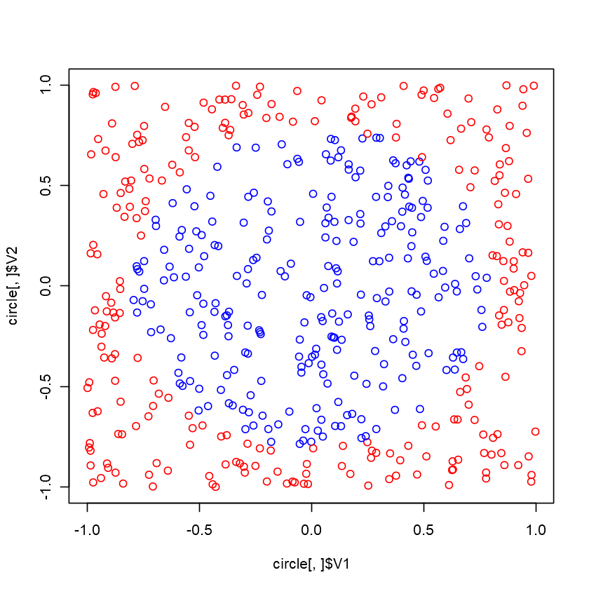

```r
class.index<-dim(circle)[2]
plot(circle[,]$V1,circle[,]$V2,xlim=c(-1,1),ylim=c(-1,1),col=c("blue","black","red")[circle[,]$labels+2])
```

```r
train.index<-sample(nrow(circle),nrow(circle)*0.3)
train.index
```

1. 459

2. 354

3. 13

4. 482

5. 116

6. 136

7. 316

8. 213

9. 224

10. 451

11. 467

12. 360

13. 267

14. 193

15. 284

16. 137

17. 328

18. 53

19. 182

20. 321

21. 293

22. 118

23. 106

24. 286

25. 162

26. 473

27. 203

28. 130

29. 313

30. 307

31. 143

32. 234

33. 361

34. 222

35. 20

36. 109

37. 289

38. 488

39. 493

40. 161

41. 351

42. 231

43. 465

44. 400

45. 469

46. 122

47. 228

48. 425

49. 31

50. 475

51. 241

52. 315

53. 325

54. 412

55. 89

56. 139

57. 445

58. 190

59. 107

60. 128

61. 129

62. 363

63. 40

64. 288

65. 382

66. 146

67. 218

68. 246

69. 249

70. 368

71. 110

72. 344

73. 205

74. 366

75. 420

76. 287

77. 86

78. 399

79. 320

80. 463

81. 113

82. 336

83. 210

84. 499

85. 219

86. 103

87. 72

88. 370

89. 387

90. 214

91. 461

92. 14

93. 491

94. 441

95. 173

96. 9

97. 314

98. 101

99. 403

100. 145

101. 436

102. 230

103. 279

104. 135

105. 29

106. 453

107. 407

108. 108

109. 92

110. 317

111. 304

112. 275

113. 494

114. 281

115. 27

116. 142

117. 409

118. 414

119. 381

120. 244

121. 259

122. 364

123. 12

124. 232

125. 17

126. 339

127. 73

128. 376

129. 202

130. 401

131. 97

132. 483

133. 127

134. 415

135. 81

136. 377

137. 212

138. 338

139. 245

140. 326

141. 112

142. 337

143. 318

144. 120

145. 324

146. 367

147. 402

148. 33

149. 330

150. 183

```r
training.set<-circle[train.index,]
training.set
```

|  | V1 | V2 | labels |
| --- | --- | --- | --- |
| 459 | -0.953707702 | 0.158214991 | 1 |
| 354 | 0.377162058 | 0.739209653 | 1 |
| 13 | 0.045367011 | 0.924229216 | 1 |
| 482 | 0.008213195 | -0.807247063 | 1 |
| 116 | 0.878132381 | -0.180204436 | 1 |
| 136 | 0.227569337 | 0.734268232 | -1 |
| 316 | -0.300581376 | -0.898516963 | 1 |
| 213 | 0.512752345 | -0.847260452 | 1 |
| 224 | 0.159647269 | -0.642042277 | -1 |
| 451 | -0.334873488 | -0.874592004 | 1 |
| 467 | 0.966850032 | 0.165503697 | 1 |
| 360 | -0.375843487 | -0.443063847 | -1 |
| 267 | 0.980529896 | 0.050735979 | 1 |
| 193 | 0.855933436 | 0.124292508 | 1 |
| 284 | -0.489151232 | -0.194107711 | -1 |
| 137 | 0.596438672 | -0.007048026 | -1 |
| 328 | 0.770281476 | -0.830577015 | 1 |
| 53 | -0.241049260 | 0.951546647 | 1 |
| 182 | 0.305645943 | 0.736848090 | -1 |
| 321 | -0.383414764 | -0.150402702 | -1 |
| 293 | -0.774137055 | -0.357319204 | 1 |
| 118 | 0.436506887 | 0.395508170 | -1 |
| 106 | 0.508584236 | 0.146206370 | -1 |
| 286 | -0.723368590 | -0.938728564 | 1 |
| 162 | -0.508722295 | -0.045524521 | -1 |
| 473 | -0.193947457 | 0.421156085 | -1 |
| 203 | 0.941996058 | 0.167771324 | 1 |
| 130 | -0.054662157 | -0.350945920 | -1 |
| 313 | 0.766390139 | -0.738573610 | 1 |
| 307 | -0.758978200 | 0.251453501 | 1 |
| ... | ... | ... | ... |
| 259 | -0.29441110 | -0.33014643 | -1 |
| 364 | -0.75177466 | -0.07522496 | -1 |
| 12 | 0.40542301 | 0.37005498 | -1 |
| 232 | 0.77883081 | -0.95724206 | 1 |
| 17 | 0.21920208 | 0.31123623 | -1 |
| 339 | -0.38465707 | 0.92792477 | 1 |
| 73 | 0.83676766 | -0.14598232 | 1 |
| 376 | 0.78070002 | 0.77897919 | 1 |
| 202 | 0.01568903 | 0.82037835 | 1 |
| 401 | 0.86044316 | -0.89068916 | 1 |
| 97 | 0.44605799 | 0.19852044 | -1 |
| 483 | -0.87509003 | -0.33855274 | 1 |
| 127 | -0.40170875 | -0.74819244 | 1 |
| 415 | -0.42678032 | -0.08516329 | -1 |
| 81 | 0.06502816 | 0.65579991 | -1 |
| 377 | 0.22339528 | -0.75587107 | -1 |
| 212 | -0.54602492 | -0.64458571 | 1 |
| 338 | -0.39482403 | 0.78707272 | 1 |
| 245 | 0.93664657 | -0.32375123 | 1 |
| 326 | -0.78678679 | 0.99568614 | 1 |
| 112 | -0.54160832 | -0.13024936 | -1 |
| 337 | -0.97215897 | -0.97676421 | 1 |
| 318 | -0.33170215 | 0.05055498 | -1 |
| 120 | 0.44858381 | 0.38951698 | -1 |
| 324 | -0.09113681 | 0.11145868 | -1 |
| 367 | -0.92335899 | -0.35558594 | 1 |
| 402 | -0.40984593 | 0.92798257 | 1 |
| 33 | 0.36475743 | -0.26425190 | -1 |
| 330 | 0.34731486 | -0.02724104 | -1 |
| 183 | -0.29636395 | -0.92788027 | 1 |

```r
training.set.features<-training.set[,-class.index]
training.set.labels<-training.set[,class.index]
training.set.labels
```

1. 1

2. 1

3. 1

4. 1

5. 1

6. -1

7. 1

8. 1

9. -1

10. 1

11. 1

12. -1

13. 1

14. 1

15. -1

16. -1

17. 1

18. 1

19. -1

20. -1

21. 1

22. -1

23. -1

24. 1

25. -1

26. -1

27. 1

28. -1

29. 1

30. 1

31. 1

32. -1

33. -1

34. -1

35. 1

36. -1

37. 1

38. 1

39. -1

40. -1

41. -1

42. 1

43. -1

44. -1

45. -1

46. 1

47. 1

48. 1

49. 1

50. -1

51. 1

52. -1

53. -1

54. 1

55. -1

56. -1

57. 1

58. 1

59. 1

60. 1

61. 1

62. 1

63. 1

64. 1

65. -1

66. 1

67. -1

68. -1

69. -1

70. 1

71. -1

72. -1

73. 1

74. -1

75. -1

76. -1

77. -1

78. 1

79. 1

80. 1

81. -1

82. -1

83. 1

84. 1

85. 1

86. -1

87. -1

88. 1

89. 1

90. -1

91. 1

92. -1

93. -1

94. -1

95. 1

96. 1

97. -1

98. -1

99. -1

100. -1

101. -1

102. 1

103. -1

104. -1

105. -1

106. -1

107. -1

108. 1

109. 1

110. 1

111. -1

112. 1

113. -1

114. -1

115. 1

116. 1

117. 1

118. -1

119. -1

120. 1

121. -1

122. -1

123. -1

124. 1

125. -1

126. 1

127. 1

128. 1

129. 1

130. 1

131. -1

132. 1

133. 1

134. -1

135. -1

136. -1

137. 1

138. 1

139. 1

140. 1

141. -1

142. 1

143. -1

144. -1

145. -1

146. 1

147. 1

148. -1

149. -1

150. 1

```r
test.set<-circle[-train.index,]
test.set
```

|  | V1 | V2 | labels |
| --- | --- | --- | --- |
| 1 | -0.36125433 | 0.77676658 | 1 |
| 2 | 0.35104327 | -0.83239241 | 1 |
| 3 | -0.35627285 | 0.92975989 | 1 |
| 4 | -0.03069027 | -0.18070132 | -1 |
| 5 | 0.94496021 | 0.97921835 | 1 |
| 6 | -0.70625080 | -0.99694213 | 1 |
| 7 | 0.99161877 | 0.99690349 | 1 |
| 8 | 0.83584269 | 0.30713464 | 1 |
| 10 | -0.17756695 | 0.37130143 | -1 |
| 11 | 0.76197443 | -0.20293592 | -1 |
| 15 | -0.30480615 | -0.61528897 | -1 |
| 16 | -0.87435384 | -0.47106882 | 1 |
| 18 | 0.10303092 | 0.31947664 | -1 |
| 19 | -0.35033518 | -0.59395713 | -1 |
| 21 | 0.12044941 | 0.64084236 | -1 |
| 22 | -0.25619249 | 0.46443524 | -1 |
| 23 | 0.34310328 | 0.49858198 | -1 |
| 24 | 0.16621527 | 0.32838838 | -1 |
| 25 | -0.03588056 | -0.76888308 | -1 |
| 26 | 0.05041501 | -0.17397570 | -1 |
| 28 | 0.86504276 | -0.45130243 | 1 |
| 30 | -0.85166635 | -0.01448331 | 1 |
| 32 | 0.02897208 | -0.71931711 | -1 |
| 34 | -0.88241886 | -0.13160632 | 1 |
| 35 | 0.52264887 | -0.33377461 | -1 |
| 36 | 0.19606415 | 0.88273518 | 1 |
| 37 | -0.76806530 | 0.71662675 | 1 |
| 38 | 0.24970607 | -0.77653605 | 1 |
| 39 | 0.12309184 | -0.17683170 | -1 |
| 41 | 0.42489162 | 0.60078024 | -1 |
| ... | ... | ... | ... |
| 456 | -0.67188690 | -0.21608583 | -1 |
| 457 | 0.73972739 | -0.01691149 | -1 |
| 458 | 0.49326846 | 0.64142884 | 1 |
| 460 | -0.22028515 | -0.04412977 | -1 |
| 462 | 0.64844526 | -0.02676766 | -1 |
| 464 | 0.04487604 | -0.39088353 | -1 |
| 466 | 0.83326895 | 0.40689094 | 1 |
| 468 | 0.72768002 | -0.66586805 | 1 |
| 470 | -0.52082891 | 0.39707271 | -1 |
| 471 | -0.54034925 | -0.47263244 | -1 |
| 472 | -0.28829425 | 0.01323212 | -1 |
| 474 | 0.27474982 | 0.12387255 | -1 |
| 476 | 0.02163063 | -0.31190543 | -1 |
| 477 | 0.46916259 | -0.04312447 | -1 |
| 478 | -0.91721746 | 0.67389973 | 1 |
| 479 | -0.79776475 | 0.70758251 | 1 |
| 480 | -0.85309980 | 0.02438959 | 1 |
| 481 | -0.55822695 | 0.74080376 | 1 |
| 484 | -0.94336902 | -0.19136623 | 1 |
| 485 | 0.31161490 | 0.26388053 | -1 |
| 486 | 0.67592021 | 0.39697837 | -1 |
| 487 | 0.04403945 | -0.15464237 | -1 |
| 489 | -0.13693843 | 0.07462970 | -1 |
| 490 | -0.88911933 | -0.35960385 | 1 |
| 492 | -0.97476089 | -0.63087402 | 1 |
| 495 | -0.28240040 | 0.08456959 | -1 |
| 496 | 0.63936695 | -0.41557695 | -1 |
| 497 | -0.97290176 | -0.21816634 | 1 |
| 498 | 0.69006885 | 0.31366387 | -1 |
| 500 | -0.10887655 | -0.98229180 | 1 |

```r
test.set.features<-test.set[,-class.index]
test.set.labels<-test.set[,class.index]
test.set.labels
```

1. 1

2. 1

3. 1

4. -1

5. 1

6. 1

7. 1

8. 1

9. -1

10. -1

11. -1

12. 1

13. -1

14. -1

15. -1

16. -1

17. -1

18. -1

19. -1

20. -1

21. 1

22. 1

23. -1

24. 1

25. -1

26. 1

27. 1

28. 1

29. -1

30. -1

31. 1

32. -1

33. 1

34. 1

35. -1

36. 1

37. 1

38. -1

39. 1

40. 1

41. -1

42. -1

43. -1

44. -1

45. 1

46. 1

47. 1

48. -1

49. 1

50. -1

51. 1

52. 1

53. 1

54. 1

55. -1

56. -1

57. -1

58. -1

59. -1

60. -1

61. -1

62. 1

63. -1

64. -1

65. 1

66. -1

67. -1

68. -1

69. 1

70. 1

71. -1

72. -1

73. 1

74. -1

75. -1

76. -1

77. 1

78. -1

79. 1

80. -1

81. -1

82. 1

83. 1

84. -1

85. -1

86. 1

87. -1

88. -1

89. 1

90. -1

91. -1

92. -1

93. 1

94. 1

95. 1

96. -1

97. -1

98. 1

99. -1

100. 1

101. 1

102. -1

103. 1

104. 1

105. -1

106. 1

107. 1

108. 1

109. 1

110. 1

111. -1

112. -1

113. 1

114. 1

115. -1

116. 1

117. 1

118. -1

119. -1

120. 1

121. 1

122. -1

123. 1

124. 1

125. 1

126. -1

127. -1

128. 1

129. -1

130. -1

131. -1

132. -1

133. 1

134. 1

135. -1

136. 1

137. -1

138. -1

139. 1

140. 1

141. 1

142. -1

143. 1

144. -1

145. -1

146. 1

147. 1

148. -1

149. 1

150. 1

151. -1

152. 1

153. 1

154. 1

155. -1

156. 1

157. 1

158. 1

159. -1

160. 1

161. 1

162. -1

163. 1

164. 1

165. 1

166. 1

167. -1

168. -1

169. -1

170. -1

171. -1

172. -1

173. -1

174. 1

175. -1

176. 1

177. -1

178. 1

179. 1

180. 1

181. -1

182. -1

183. -1

184. 1

185. 1

186. -1

187. 1

188. 1

189. -1

190. 1

191. 1

192. 1

193. 1

194. 1

195. -1

196. -1

197. 1

198. -1

199. -1

200. -1

201. 1

202. 1

203. 1

204. -1

205. -1

206. -1

207. -1

208. -1

209. 1

210. 1

211. -1

212. 1

213. 1

214. -1

215. 1

216. 1

217. -1

218. -1

219. -1

220. 1

221. -1

222. -1

223. -1

224. 1

225. 1

226. -1

227. -1

228. 1

229. -1

230. 1

231. -1

232. -1

233. -1

234. 1

235. 1

236. 1

237. -1

238. -1

239. 1

240. 1

241. 1

242. 1

243. -1

244. -1

245. 1

246. 1

247. 1

248. 1

249. -1

250. 1

251. -1

252. -1

253. -1

254. -1

255. -1

256. -1

257. -1

258. 1

259. -1

260. -1

261. -1

262. -1

263. -1

264. 1

265. 1

266. 1

267. 1

268. -1

269. -1

270. 1

271. 1

272. 1

273. -1

274. -1

275. 1

276. 1

277. 1

278. 1

279. 1

280. 1

281. -1

282. -1

283. 1

284. 1

285. -1

286. 1

287. 1

288. -1

289. 1

290. -1

291. -1

292. -1

293. 1

294. 1

295. 1

296. -1

297. -1

298. -1

299. 1

300. 1

301. -1

302. 1

303. 1

304. -1

305. 1

306. -1

307. -1

308. -1

309. 1

310. 1

311. 1

312. -1

313. 1

314. -1

315. 1

316. 1

317. 1

318. -1

319. -1

320. -1

321. -1

322. -1

323. 1

324. -1

325. -1

326. -1

327. 1

328. 1

329. -1

330. -1

331. -1

332. -1

333. -1

334. -1

335. 1

336. 1

337. 1

338. 1

339. 1

340. -1

341. -1

342. -1

343. -1

344. 1

345. 1

346. -1

347. -1

348. 1

349. -1

350. 1

Next we provide a function to train the RBF network and execute the training. We will train an RBF model with 2 centers, 5 centers, and 10 centers, respectively.

```r
rbf <- function(X, Y, K, gamma=1.0) {
  N<- dim(X)[1] # number of instances

  repeat {
    km <- kmeans(X, K)  # let's cluster K centers out of the dataset
    if (min(km$size)>0) # only accept if there are no empty clusters
      break
  }
  mus <- km$centers # the clusters points

  Phi <- matrix(rep(NA,(K+1)*N), ncol=K+1)
  for (lin in 1:N) {
    Phi[lin,1] <- 1    # bias column
    for (col in 1:K) {
      Phi[lin,col+1] <- exp( -gamma * norm(as.matrix(X[lin,]-mus[col,]),"F")^2 )
    }
  }
#  w <- pseudoinverse(t(Phi) %*% Phi) %*% t(Phi) %*% matrix(as.numeric(Y))  # find RBF weights
  w <- pseudoinverse(Phi) %*% matrix(as.numeric(Y))  # find RBF weights
  list(weights=w, centers=mus, gamma=gamma)  # return the rbf model
}
# now call rbf function
rbf.model.2<-rbf(training.set.features,training.set.labels, 2)
rbf.model.2
```

**$weights**

| 2.623843 |
| --- |
| -2.386206 |
| -3.022563 |

**$centers**

| V1 | V2 |
| --- | --- |
| -0.11450799 | -0.5841307 |
| 0.08854528 | 0.4610525 |

**$gamma**

1

```r
rbf.model.5<-rbf(training.set.features,training.set.labels, 5)
rbf.model.5
```

**$weights**

| 3.999352 |
| --- |
| -2.826701 |
| -2.080293 |
| -1.608306 |
| -1.024512 |
| -2.039939 |

**$centers**

| V1 | V2 |
| --- | --- |
| 0.46514543 | 0.3614045 |
| -0.61532480 | -0.3645666 |
| 0.67132315 | -0.6182762 |
| -0.07719623 | -0.7495990 |
| -0.52348814 | 0.6689460 |

**$gamma**

1

```r
rbf.model.10<-rbf(training.set.features,training.set.labels, 10)
rbf.model.10
```

**$weights**

| 5.799698 |
| --- |
| -5.908817 |
| -4.114527 |
| -5.153639 |
| -2.546680 |
| 2.967465 |
| 2.361171 |
| -7.380517 |
| 5.551373 |
| -6.357244 |
| 4.031228 |

**$centers**

| V1 | V2 |
| --- | --- |
| -0.21646251 | -0.22203213 |
| -0.90507141 | 0.90887914 |
| 0.66807916 | -0.79844654 |
| -0.69304176 | 0.37817038 |
| -0.09949302 | -0.82908969 |
| 0.64903817 | -0.01139611 |
| 0.40680471 | 0.58113402 |
| -0.69722710 | -0.21572379 |
| -0.78075151 | -0.68045686 |
| -0.18400896 | 0.76770293 |

**$gamma**

1

Next we provide a function to make predictions using our trained models:

```r
rbf.predict <- function(model, X, classification=FALSE) {
  gamma   <- model$gamma
  centers <- model$centers
  w       <- model$weights
  N       <- dim(X)[1]    # number of observations

  pred <- rep(w[1],N)  # we need to init to a value, so let's start with the bias
  for (j in 1:N) {
    # find prediction for point xj
    for (k in 1:length(centers[,1])) {
      # the weight for center[k] is given by w[k+1] (because w[1] is the bias)
      pred[j] <- pred[j] + w[k+1] * exp( -gamma * norm(as.matrix(X[j,]-centers[k,]),"F")^2 )
    }
  }

  if (classification) {
    pred <- unlist(lapply(pred, sign))
  }
  return(pred)
}
predictions.2<-rbf.predict(rbf.model.2,test.set.features,TRUE)
predictions.2
```

1. 1

2. 1

3. 1

4. -1

5. 1

6. 1

7. 1

8. 1

9. -1

10. 1

11. -1

12. 1

13. -1

14. -1

15. -1

16. -1

17. -1

18. -1

19. -1

20. -1

21. 1

22. 1

23. -1

24. 1

25. -1

26. -1

27. 1

28. -1

29. -1

30. -1

31. -1

32. -1

33. 1

34. 1

35. -1

36. 1

37. 1

38. -1

39. 1

40. 1

41. -1

42. -1

43. -1

44. -1

45. 1

46. 1

47. 1

48. -1

49. 1

50. -1

51. 1

52. 1

53. 1

54. 1

55. -1

56. -1

57. -1

58. -1

59. -1

60. -1

61. 1

62. 1

63. -1

64. -1

65. 1

66. -1

67. -1

68. -1

69. 1

70. 1

71. -1

72. 1

73. -1

74. -1

75. -1

76. -1

77. 1

78. -1

79. 1

80. -1

81. -1

82. 1

83. 1

84. 1

85. -1

86. 1

87. -1

88. -1

89. 1

90. -1

91. -1

92. -1

93. 1

94. 1

95. 1

96. -1

97. -1

98. 1

99. -1

100. 1

101. 1

102. -1

103. 1

104. -1

105. -1

106. 1

107. 1

108. 1

109. 1

110. 1

111. -1

112. -1

113. 1

114. 1

115. -1

116. 1

117. 1

118. -1

119. -1

120. 1

121. 1

122. -1

123. -1

124. 1

125. 1

126. -1

127. 1

128. 1

129. 1

130. -1

131. -1

132. 1

133. 1

134. 1

135. -1

136. 1

137. -1

138. -1

139. 1

140. 1

141. 1

142. -1

143. 1

144. -1

145. -1

146. 1

147. 1

148. -1

149. 1

150. 1

151. -1

152. 1

153. 1

154. 1

155. 1

156. -1

157. 1

158. 1

159. 1

160. 1

161. 1

162. -1

163. 1

164. 1

165. 1

166. 1

167. -1

168. -1

169. -1

170. 1

171. -1

172. -1

173. -1

174. 1

175. -1

176. 1

177. -1

178. 1

179. 1

180. 1

181. -1

182. -1

183. -1

184. 1

185. 1

186. -1

187. 1

188. 1

189. 1

190. -1

191. 1

192. 1

193. 1

194. 1

195. -1

196. -1

197. 1

198. -1

199. 1

200. -1

201. 1

202. 1

203. 1

204. -1

205. -1

206. -1

207. -1

208. -1

209. -1

210. 1

211. -1

212. 1

213. 1

214. -1

215. 1

216. 1

217. -1

218. -1

219. -1

220. 1

221. -1

222. -1

223. -1

224. 1

225. 1

226. 1

227. 1

228. -1

229. -1

230. -1

231. -1

232. -1

233. -1

234. 1

235. -1

236. -1

237. -1

238. 1

239. 1

240. 1

241. 1

242. 1

243. -1

244. -1

245. 1

246. -1

247. 1

248. 1

249. -1

250. 1

251. -1

252. -1

253. -1

254. -1

255. -1

256. -1

257. -1

258. 1

259. -1

260. -1

261. -1

262. -1

263. 1

264. 1

265. 1

266. 1

267. 1

268. -1

269. -1

270. 1

271. 1

272. 1

273. -1

274. -1

275. 1

276. 1

277. 1

278. 1

279. 1

280. 1

281. -1

282. -1

283. -1

284. 1

285. -1

286. 1

287. 1

288. -1

289. 1

290. -1

291. -1

292. -1

293. 1

294. 1

295. 1

296. -1

297. -1

298. -1

299. 1

300. 1

301. -1

302. 1

303. -1

304. -1

305. 1

306. -1

307. -1

308. -1

309. -1

310. 1

311. 1

312. -1

313. 1

314. 1

315. 1

316. 1

317. 1

318. -1

319. -1

320. -1

321. 1

322. 1

323. -1

324. -1

325. -1

326. -1

327. 1

328. 1

329. -1

330. -1

331. -1

332. -1

333. -1

334. -1

335. 1

336. 1

337. 1

338. 1

339. 1

340. -1

341. 1

342. -1

343. -1

344. 1

345. 1

346. -1

347. 1

348. 1

349. 1

350. 1

```r
predictions.5<-rbf.predict(rbf.model.5,test.set.features,TRUE)
predictions.5
```

1. 1

2. 1

3. 1

4. -1

5. 1

6. 1

7. 1

8. 1

9. -1

10. -1

11. -1

12. 1

13. -1

14. -1

15. -1

16. -1

17. -1

18. -1

19. -1

20. -1

21. 1

22. 1

23. -1

24. 1

25. -1

26. 1

27. 1

28. 1

29. -1

30. -1

31. 1

32. -1

33. 1

34. 1

35. -1

36. 1

37. 1

38. -1

39. 1

40. 1

41. -1

42. -1

43. -1

44. -1

45. 1

46. 1

47. 1

48. 1

49. 1

50. -1

51. 1

52. 1

53. 1

54. 1

55. -1

56. -1

57. -1

58. -1

59. -1

60. -1

61. -1

62. 1

63. -1

64. -1

65. 1

66. -1

67. -1

68. -1

69. 1

70. 1

71. -1

72. -1

73. 1

74. -1

75. -1

76. -1

77. 1

78. -1

79. 1

80. -1

81. -1

82. 1

83. 1

84. -1

85. -1

86. 1

87. -1

88. -1

89. 1

90. -1

91. -1

92. -1

93. 1

94. 1

95. 1

96. -1

97. -1

98. 1

99. -1

100. 1

101. 1

102. -1

103. 1

104. 1

105. -1

106. 1

107. 1

108. 1

109. 1

110. 1

111. -1

112. -1

113. 1

114. 1

115. -1

116. 1

117. 1

118. -1

119. -1

120. 1

121. 1

122. -1

123. 1

124. 1

125. 1

126. -1

127. -1

128. 1

129. -1

130. -1

131. -1

132. 1

133. 1

134. 1

135. -1

136. 1

137. -1

138. -1

139. 1

140. 1

141. 1

142. -1

143. 1

144. -1

145. 1

146. 1

147. 1

148. -1

149. 1

150. 1

151. -1

152. 1

153. 1

154. 1

155. -1

156. 1

157. 1

158. 1

159. -1

160. 1

161. 1

162. -1

163. 1

164. 1

165. 1

166. 1

167. -1

168. -1

169. -1

170. -1

171. -1

172. -1

173. -1

174. 1

175. -1

176. 1

177. -1

178. 1

179. 1

180. 1

181. -1

182. -1

183. -1

184. 1

185. 1

186. -1

187. 1

188. 1

189. -1

190. 1

191. 1

192. 1

193. 1

194. 1

195. -1

196. -1

197. 1

198. -1

199. -1

200. -1

201. 1

202. 1

203. 1

204. -1

205. -1

206. -1

207. -1

208. -1

209. 1

210. 1

211. -1

212. 1

213. 1

214. -1

215. 1

216. 1

217. -1

218. -1

219. -1

220. 1

221. -1

222. -1

223. -1

224. 1

225. 1

226. -1

227. 1

228. 1

229. -1

230. 1

231. 1

232. -1

233. -1

234. 1

235. 1

236. 1

237. -1

238. -1

239. 1

240. 1

241. 1

242. 1

243. -1

244. -1

245. 1

246. 1

247. 1

248. 1

249. -1

250. 1

251. -1

252. -1

253. -1

254. -1

255. -1

256. -1

257. -1

258. 1

259. -1

260. -1

261. -1

262. -1

263. -1

264. 1

265. 1

266. 1

267. 1

268. -1

269. -1

270. 1

271. 1

272. -1

273. -1

274. -1

275. 1

276. 1

277. 1

278. 1

279. 1

280. 1

281. -1

282. -1

283. 1

284. 1

285. -1

286. 1

287. 1

288. -1

289. 1

290. -1

291. -1

292. -1

293. 1

294. 1

295. 1

296. -1

297. -1

298. -1

299. 1

300. 1

301. -1

302. 1

303. 1

304. -1

305. 1

306. -1

307. -1

308. -1

309. 1

310. 1

311. 1

312. -1

313. 1

314. -1

315. 1

316. 1

317. 1

318. -1

319. -1

320. -1

321. -1

322. -1

323. 1

324. -1

325. -1

326. -1

327. 1

328. 1

329. -1

330. -1

331. -1

332. -1

333. -1

334. -1

335. 1

336. 1

337. 1

338. 1

339. 1

340. -1

341. -1

342. -1

343. -1

344. 1

345. 1

346. -1

347. -1

348. 1

349. -1

350. 1

```r
predictions.10<-rbf.predict(rbf.model.10,test.set.features,TRUE)
predictions.10
```

1. 1

2. 1

3. 1

4. -1

5. 1

6. 1

7. 1

8. 1

9. -1

10. 1

11. -1

12. 1

13. -1

14. -1

15. -1

16. -1

17. -1

18. -1

19. 1

20. -1

21. 1

22. 1

23. -1

24. 1

25. -1

26. 1

27. 1

28. 1

29. -1

30. -1

31. 1

32. -1

33. 1

34. 1

35. -1

36. 1

37. 1

38. -1

39. 1

40. 1

41. -1

42. -1

43. -1

44. -1

45. 1

46. 1

47. 1

48. 1

49. 1

50. -1

51. 1

52. 1

53. 1

54. 1

55. -1

56. -1

57. -1

58. -1

59. -1

60. -1

61. -1

62. 1

63. -1

64. -1

65. 1

66. -1

67. -1

68. -1

69. 1

70. 1

71. -1

72. 1

73. 1

74. -1

75. -1

76. -1

77. 1

78. -1

79. -1

80. -1

81. -1

82. 1

83. 1

84. -1

85. -1

86. 1

87. -1

88. -1

89. 1

90. -1

91. -1

92. -1

93. 1

94. 1

95. 1

96. -1

97. -1

98. 1

99. -1

100. 1

101. 1

102. -1

103. 1

104. 1

105. -1

106. 1

107. 1

108. 1

109. 1

110. 1

111. -1

112. -1

113. -1

114. 1

115. -1

116. 1

117. 1

118. -1

119. -1

120. 1

121. 1

122. -1

123. -1

124. 1

125. 1

126. -1

127. -1

128. 1

129. 1

130. -1

131. -1

132. 1

133. 1

134. 1

135. -1

136. 1

137. -1

138. -1

139. 1

140. 1

141. 1

142. -1

143. 1

144. -1

145. -1

146. 1

147. 1

148. -1

149. 1

150. 1

151. -1

152. 1

153. 1

154. 1

155. 1

156. 1

157. 1

158. 1

159. 1

160. 1

161. 1

162. -1

163. 1

164. 1

165. 1

166. 1

167. -1

168. -1

169. -1

170. 1

171. -1

172. -1

173. -1

174. 1

175. -1

176. 1

177. -1

178. 1

179. 1

180. 1

181. -1

182. -1

183. -1

184. 1

185. 1

186. -1

187. 1

188. 1

189. 1

190. 1

191. 1

192. 1

193. 1

194. 1

195. -1

196. -1

197. 1

198. -1

199. -1

200. -1

201. 1

202. 1

203. 1

204. -1

205. -1

206. -1

207. -1

208. -1

209. 1

210. 1

211. -1

212. 1

213. 1

214. 1

215. 1

216. 1

217. -1

218. -1

219. -1

220. 1

221. -1

222. -1

223. -1

224. 1

225. 1

226. -1

227. 1

228. 1

229. -1

230. 1

231. 1

232. -1

233. -1

234. 1

235. 1

236. 1

237. -1

238. -1

239. 1

240. 1

241. 1

242. 1

243. -1

244. -1

245. 1

246. 1

247. 1

248. 1

249. -1

250. 1

251. -1

252. -1

253. -1

254. -1

255. -1

256. -1

257. -1

258. 1

259. -1

260. -1

261. -1

262. -1

263. -1

264. 1

265. 1

266. 1

267. 1

268. -1

269. -1

270. 1

271. 1

272. 1

273. -1

274. -1

275. 1

276. 1

277. 1

278. 1

279. 1

280. 1

281. -1

282. -1

283. 1

284. 1

285. -1

286. 1

287. 1

288. -1

289. 1

290. -1

291. -1

292. -1

293. 1

294. 1

295. -1

296. -1

297. -1

298. -1

299. 1

300. 1

301. -1

302. 1

303. 1

304. -1

305. 1

306. -1

307. -1

308. -1

309. 1

310. 1

311. 1

312. -1

313. 1

314. -1

315. 1

316. 1

317. 1

318. -1

319. -1

320. -1

321. -1

322. 1

323. -1

324. -1

325. -1

326. -1

327. 1

328. 1

329. -1

330. -1

331. -1

332. -1

333. -1

334. -1

335. 1

336. 1

337. 1

338. 1

339. 1

340. -1

341. -1

342. -1

343. -1

344. 1

345. 1

346. -1

347. -1

348. 1

349. -1

350. 1

Next we present the confusion matrices to validate the predictions:

```r
cm.2<-table(test.set.labels,predictions.2)
cm.2
```

```
               predictions.2
test.set.labels  -1   1
             -1 155  22
             1   18 155
```

```r
cm.5<-table(test.set.labels,predictions.5)
cm.5
```

```
               predictions.5
test.set.labels  -1   1
             -1 172   5
             1    1 172
```

```r
cm.10<-table(test.set.labels,predictions.10)
cm.10
```

```
               predictions.10
test.set.labels  -1   1
             -1 163  14
             1    5 168
```

```r
acc.2<-(cm.2[1][1]+cm.2[4][1])/sum(cm.2)
caption.2<-sprintf("RBF Accuracy: %.4f",acc.2)
caption.2
```

'RBF Accuracy: 0.8857'

```r
acc.5<-(cm.5[1][1]+cm.5[4][1])/sum(cm.5)
caption.5<-sprintf("RBF Accuracy: %.4f",acc.5)
caption.5
```

'RBF Accuracy: 0.9829'

```r
acc.10<-(cm.10[1][1]+cm.10[4][1])/sum(cm.10)
caption.10<-sprintf("RBF Accuracy: %.4f",acc.10)
caption.10
```

'RBF Accuracy: 0.9457'

Next we visualize the predictions with the RBF centers:

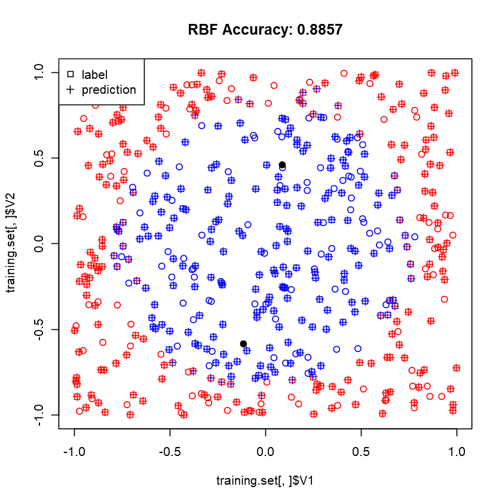

```r
plot(training.set[,]$V1,training.set[,]$V2,xlim=c(-1,1),ylim=c(-1,1),col=c("blue","black","red")[training.set.labels[]+2])
points(test.set[,1],test.set[,2],col=c("blue","black","red")[predictions.2[]+2],pch=3)
points(test.set[,1],test.set[,2],col=c("blue","black","red")[test.set.labels[]+2],pch=0)
points(rbf.model.2$centers, col="black", pch=19)
legend("topleft",legend=c("label","prediction"),pch=c(0,3))
title(caption.2)
```

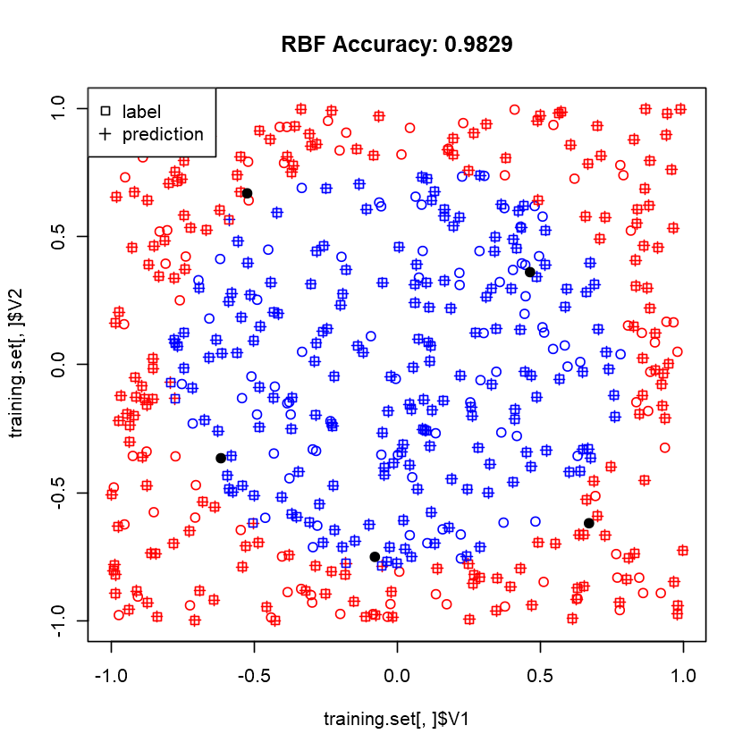

```r
plot(training.set[,]$V1,training.set[,]$V2,xlim=c(-1,1),ylim=c(-1,1),col=c("blue","black","red")[training.set.labels[]+2])
points(test.set[,1],test.set[,2],col=c("blue","black","red")[predictions.5[]+2],pch=3)
points(test.set[,1],test.set[,2],col=c("blue","black","red")[test.set.labels[]+2],pch=0)
points(rbf.model.5$centers, col="black", pch=19)
legend("topleft",legend=c("label","prediction"),pch=c(0,3))
title(caption.5)
```

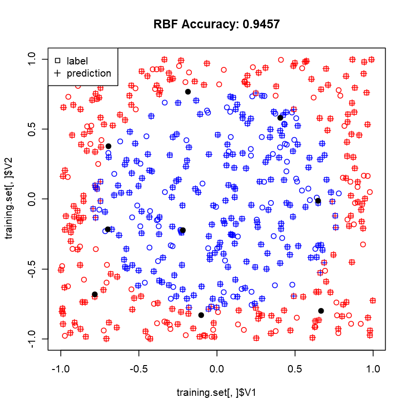

```r
plot(training.set[,]$V1,training.set[,]$V2,xlim=c(-1,1),ylim=c(-1,1),col=c("blue","black","red")[training.set.labels[]+2])
points(test.set[,1],test.set[,2],col=c("blue","black","red")[predictions.10[]+2],pch=3)
points(test.set[,1],test.set[,2],col=c("blue","black","red")[test.set.labels[]+2],pch=0)
points(rbf.model.10$centers, col="black", pch=19)
legend("topleft",legend=c("label","prediction"),pch=c(0,3))
title(caption.10)
```

Next we compare the performance of an RBF network with 2 centers, 5 centers, and 10 centers to the performance of a neural network with 1 hidden layer containing 2 hidden nodes, 5 hidden nodes, and 10 hidden nodes, respectively. We perform the same process with the neural network as we did with the RBF network:

```r
library(neuralnet)
nrepeats<-5
net.2<-neuralnet(labels ~ V1+V2,training.set,hidden=2,rep=nrepeats)
summary(net.2)
```

```
                    Length Class      Mode
call                  5    -none-     call
response            150    -none-     numeric
covariate           300    -none-     numeric
model.list            2    -none-     list
err.fct               1    -none-     function
act.fct               1    -none-     function
linear.output         1    -none-     logical
data                  3    data.frame list
exclude               0    -none-     NULL
net.result            5    -none-     list
weights               5    -none-     list
generalized.weights   5    -none-     list
startweights          5    -none-     list
result.matrix        60    -none-     numeric
```

```r
net.5<-neuralnet(labels ~ V1+V2,training.set,hidden=5,rep=nrepeats)
summary(net.5)
```

```
                    Length Class      Mode
call                  5    -none-     call
response            150    -none-     numeric
covariate           300    -none-     numeric
model.list            2    -none-     list
err.fct               1    -none-     function
act.fct               1    -none-     function
linear.output         1    -none-     logical
data                  3    data.frame list
exclude               0    -none-     NULL
net.result            5    -none-     list
weights               5    -none-     list
generalized.weights   5    -none-     list
startweights          5    -none-     list
result.matrix       120    -none-     numeric
```

```r
net.10<-neuralnet(labels ~ V1+V2,training.set,hidden=10,rep=nrepeats)
summary(net.10)
```

```
                    Length Class      Mode
call                  5    -none-     call
response            150    -none-     numeric
covariate           300    -none-     numeric
model.list            2    -none-     list
err.fct               1    -none-     function
act.fct               1    -none-     function
linear.output         1    -none-     logical
data                  3    data.frame list
exclude               0    -none-     NULL
net.result            5    -none-     list
weights               5    -none-     list
generalized.weights   5    -none-     list
startweights          5    -none-     list
result.matrix       220    -none-     numeric
```

```r
nn.predictions.2<-predict(net.2,test.set[,-3])
nn.predictions.2<-ifelse(nn.predictions.2>0.5,1,-1)
nn.predictions.2
```

| 1 | -1 |
| --- | --- |
| 2 | 1 |
| 3 | -1 |
| 4 | -1 |
| 5 | -1 |
| 6 | -1 |
| 7 | -1 |
| 8 | -1 |
| 10 | -1 |
| 11 | -1 |
| 15 | -1 |
| 16 | 1 |
| 18 | -1 |
| 19 | -1 |
| 21 | -1 |
| 22 | -1 |
| 23 | -1 |
| 24 | -1 |
| 25 | -1 |
| 26 | -1 |
| 28 | 1 |
| 30 | 1 |
| 32 | -1 |
| 34 | 1 |
| 35 | -1 |
| 36 | -1 |
| 37 | 1 |
| 38 | 1 |
| 39 | -1 |
| 41 | -1 |
| ... | ... |
| 456 | -1 |
| 457 | -1 |
| 458 | -1 |
| 460 | -1 |
| 462 | -1 |
| 464 | -1 |
| 466 | -1 |
| 468 | 1 |
| 470 | -1 |
| 471 | -1 |
| 472 | -1 |
| 474 | -1 |
| 476 | -1 |
| 477 | -1 |
| 478 | 1 |
| 479 | 1 |
| 480 | 1 |
| 481 | 1 |
| 484 | 1 |
| 485 | -1 |
| 486 | -1 |
| 487 | -1 |
| 489 | -1 |
| 490 | 1 |
| 492 | 1 |
| 495 | -1 |
| 496 | 1 |
| 497 | 1 |
| 498 | -1 |
| 500 | 1 |

```r
nn.predictions.5<-predict(net.5,test.set[,-3])
nn.predictions.5<-ifelse(nn.predictions.5>0.5,1,-1)
nn.predictions.5
```

| 1 | 1 |
| --- | --- |
| 2 | -1 |
| 3 | 1 |
| 4 | -1 |
| 5 | 1 |
| 6 | 1 |
| 7 | 1 |
| 8 | 1 |
| 10 | -1 |
| 11 | -1 |
| 15 | -1 |
| 16 | 1 |
| 18 | -1 |
| 19 | -1 |
| 21 | -1 |
| 22 | -1 |
| 23 | -1 |
| 24 | -1 |
| 25 | -1 |
| 26 | -1 |
| 28 | 1 |
| 30 | -1 |
| 32 | -1 |
| 34 | -1 |
| 35 | -1 |
| 36 | -1 |
| 37 | 1 |
| 38 | -1 |
| 39 | -1 |
| 41 | -1 |
| ... | ... |
| 456 | -1 |
| 457 | -1 |
| 458 | -1 |
| 460 | -1 |
| 462 | -1 |
| 464 | -1 |
| 466 | 1 |
| 468 | 1 |
| 470 | -1 |
| 471 | -1 |
| 472 | -1 |
| 474 | -1 |
| 476 | -1 |
| 477 | -1 |
| 478 | 1 |
| 479 | 1 |
| 480 | -1 |
| 481 | 1 |
| 484 | 1 |
| 485 | -1 |
| 486 | -1 |
| 487 | -1 |
| 489 | -1 |
| 490 | 1 |
| 492 | 1 |
| 495 | -1 |
| 496 | -1 |
| 497 | 1 |
| 498 | -1 |
| 500 | 1 |

```r
nn.predictions.10<-predict(net.10,test.set[,-3])
nn.predictions.10<-ifelse(nn.predictions.10>0.5,1,-1)
nn.predictions.10
```

| 1 | -1 |
| --- | --- |
| 2 | -1 |
| 3 | 1 |
| 4 | -1 |
| 5 | 1 |
| 6 | 1 |
| 7 | 1 |
| 8 | 1 |
| 10 | -1 |
| 11 | -1 |
| 15 | -1 |
| 16 | 1 |
| 18 | -1 |
| 19 | -1 |
| 21 | -1 |
| 22 | -1 |
| 23 | -1 |
| 24 | -1 |
| 25 | -1 |
| 26 | -1 |
| 28 | 1 |
| 30 | -1 |
| 32 | -1 |
| 34 | -1 |
| 35 | -1 |
| 36 | 1 |
| 37 | 1 |
| 38 | -1 |
| 39 | -1 |
| 41 | -1 |
| ... | ... |
| 456 | -1 |
| 457 | -1 |
| 458 | -1 |
| 460 | -1 |
| 462 | -1 |
| 464 | -1 |
| 466 | 1 |
| 468 | 1 |
| 470 | -1 |
| 471 | -1 |
| 472 | -1 |
| 474 | -1 |
| 476 | -1 |
| 477 | -1 |
| 478 | 1 |
| 479 | 1 |
| 480 | -1 |
| 481 | 1 |
| 484 | -1 |
| 485 | -1 |
| 486 | -1 |
| 487 | -1 |
| 489 | -1 |
| 490 | 1 |
| 492 | 1 |
| 495 | -1 |
| 496 | -1 |
| 497 | -1 |
| 498 | -1 |
| 500 | 1 |

```r
nn.cm.2<-table(test.set.labels,nn.predictions.2)
nn.cm.2
```

```
               nn.predictions.2
test.set.labels  -1   1
             -1 168   9
             1   90  83
```

```r
nn.cm.5<-table(test.set.labels,nn.predictions.5)
nn.cm.5
```

```
               nn.predictions.5
test.set.labels  -1   1
             -1 176   1
             1   51 122
```

```r
nn.cm.10<-table(test.set.labels,nn.predictions.10)
nn.cm.10
```

```
               nn.predictions.10
test.set.labels  -1   1
             -1 177   0
             1   40 133
```

```r
nn.acc.2<-(nn.cm.2[1][1]+nn.cm.2[4][1])/sum(nn.cm.2)
nn.caption.2<-sprintf("One Hidden Layer (%d nodes) NN Accuracy: %.4f",2,nn.acc.2)
nn.caption.2
```

'One Hidden Layer (2 nodes) NN Accuracy: 0.7171'

```r
nn.acc.5<-(nn.cm.5[1][1]+nn.cm.5[4][1])/sum(nn.cm.5)
nn.caption.5<-sprintf("One Hidden Layer (%d nodes) NN Accuracy: %.4f",5,nn.acc.5)
nn.caption.5
```

'One Hidden Layer (5 nodes) NN Accuracy: 0.8514'

```r
nn.acc.10<-(nn.cm.10[1][1]+nn.cm.10[4][1])/sum(nn.cm.10)
nn.caption.10<-sprintf("One Hidden Layer (%d nodes) NN Accuracy: %.4f",10,nn.acc.10)
nn.caption.10
```

'One Hidden Layer (10 nodes) NN Accuracy: 0.8857'

Finally we compare the performance of the two network types:

```r
rbf.accuracy.vector<-c(acc.2, acc.5, acc.10)
nn.accuracy.vector<-c(nn.acc.2, nn.acc.5, nn.acc.10)
cenhid.vector<-c(2, 5, 10)
accuracy.comp.frame<-as.data.frame(cbind(rbf.accuracy.vector, nn.accuracy.vector, cenhid.vector))
names(accuracy.comp.frame)<-c("RBF Accuracy", "NN Accuracy", "Centers/Hidden Nodes")
accuracy.comp.frame
```

| RBF Accuracy | NN Accuracy | Centers/Hidden Nodes |
| --- | --- | --- |
| 0.8857143 | 0.7171429 | 2 |
| 0.9828571 | 0.8514286 | 5 |
| 0.9457143 | 0.8857143 | 10 |

It is evident from these results that the RBF network performs much better on this datset than a Neural Network with one hidden layer. Also, it took much more time to train the Neural Network than it did the RBF network. The best overall performance was obtained with an RBF network with 5 centers.